# Healthcare: Where’s the Money Going?

SDS 313 Project 2

Bailey Inglish

11/10/2023

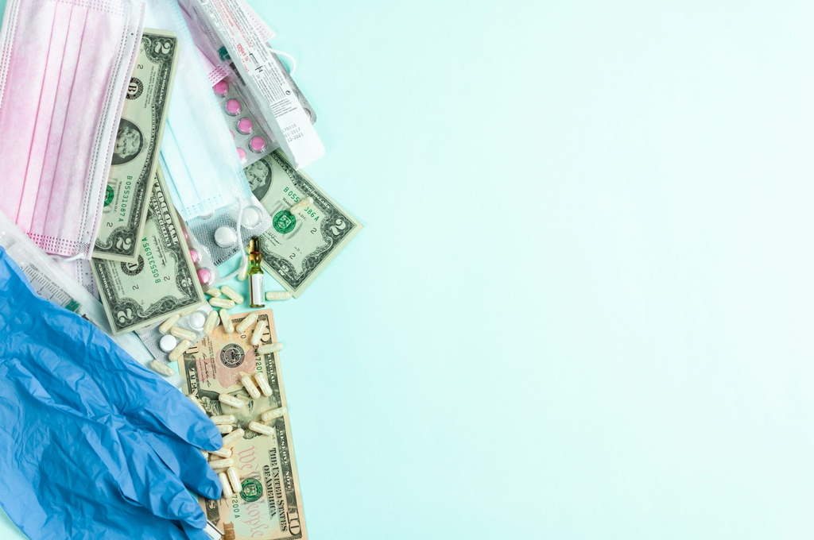

Caption: Medical supplies with money. From [Anastasiia Gudantova on Unsplash](https://unsplash.com/photos/a-medical-mask-medical-supplies-and-money-on-a-blue-background-l2iCYoXeBkY) (Gudantova, 2023)

## Introduction (1)

This report examines trends in healthcare spending and the compensation of providers by medical companies. The data used in it are available to the public for free online from the United States Centers for Medicare and Medicaid Services (CMS):

- [Medicare Part D Prescribers - by Provider (MPD)](https://data.cms.gov/provider-summary-by-type-of-service/medicare-part-d-prescribers/medicare-part-d-prescribers-by-provider)
- [Open Payments Data (OP)](https://openpaymentsdata.cms.gov/dataset/0380bbeb-aea1-58b6-b708-829f92a48202)

The MPD data provide a high-level view of the healthcare offered to Medicare beneficiaries organized by prescriber. The OP data offer a very granular look at Medicare provider compensation by medical companies, in the form an individual entry for each unique payment. These datasets can also be crosswalked by National Provider Identifier (NPI).

Note that for this report specifically, due to computational limitations, the data used were only limited to Texas data from 2021. However, the methodology should theoretically hold should the same analytical processes be applied to nation-wide data or across multiple years.

## Data Preparation & Methodology (2)

To download these datasets, the built-in web viewer interface was first used to filter them to only include Texas healthcare providers. For the MPD data, this filter was when `Prscrbr_State_Abrvtn` equals `TX`. For the OP data, the filter was when `Recipient_State` is `TX`. This was done because of limited computational resources. Only the subsets were downloaded as .csv files. The MPD data contained 84548 observations, and the OP data included 1085616 observations.

This report used R to analyze the data. To import these datasets into R, the `read_csv()` function from `readr` (a part of the `tidyverse` library of packages) was used to import the .csv files for each datasets as tibbles. The MPD dataset was imported as `mpd_raw` and the OP dataset was imported as `pay_raw`.

Then, those the variables in those datasets were renamed and filtered using `select()` from the `dplyr` package to remove extraneous variables and make the remaining variables more human-readable and consistent. The new versions of `mpd_raw` and `pay_raw` data were named `mpd_clean` and `pay_clean`, respectively.

In addition, `filter()`, also from dplyr, was used to limit `pay_clean` to only include transactions that were flagged as being in relation to at least one drug product. This is because the MPD data only include information on Medicare *Part D* prescribing. Durable medical equipment and medical devices are generally billed under Medicare *Part B*, so payments for those types of products shouldn’t infuence drug prescription and thus should be excluded.

Next, a few variables of interest were wrangled using `tidyr`’s `group_by()`, `summarize()`, and `pivot_longer()`. For each, certain variables were calculated. The `pay_by_*` tibbles all share a set of common variable names. Each of the summarized tibbles is with respect to a different grouping, either by provider NPI, by product name, or by company name. A description of the variables is below:

- *total_compensated [int]* is the total number of prescribers compensated by a company
- *total_companies [int]* is the total number of companies that a prescriber has been compensated by
- *total_compensation [dbl]* is the sum of all payments by a drug company, to a prescriber, or in relation to a product
- *mean_compensation [dbl]* is the arithmetic mean of all payments by a drug company, to a prescriber, or in relation to a product
- *median_compensation [dbl]* is the median of all payments by a drug company, to a prescriber, or in relation to a product
- *total_pbr [int]* is the total number of prescribers, compensated or uncompensated, in a specialty

Also note that `pay_by_payment_product` is an expansion of `pay_clean`. Each payment is separated into an observation for each product tagged as related to that payment. For consistency, the total compensation across all products in a single transaction is shared by all payment-product observations.

To crosswalk the data, `dplyr`’s `left_join()` function is used to merge the `mpd_clean` and `pay_by_prescriber` to get `mpd_pay`. Any prescribers who have data in `mpd_clean` but not `mpd_pay` are assumed to have not received any reportable payments in 2021, so their `total_compensation` is set to 0.

Additionally, the `payment_date` variable of `pay_clean` is parsed with `lubridate` to find the day of the week, month, and day of the month on which payments occurred. These variables are added to `pay_clean`.

One of the biggest challenges in processing this data was effectively reshaping the payments data. Because the original dataset was per-payment rather than per-product or per-company, it took some clever usage of `pivot_longer()` to make it work. In addition, the size of the dataset was an ongoing challenge because of the increased computational time.

NA values are dealt with on a case-by-case basis within each analysis. I was cognizant to avoid analyses in which NA values significantly reduced the data that was available. To remove all NA values in a dataset like this would unecessarily exclude perfectly good observations.

The number of observations in each raw dataset are included in the first paragraph of this section. While there are a number of additional tibbles that are created, the most important is `mpd_pay` which has 84548 observations.

## Data Dictionary (3)

The following table describes the variables that are directly and indirectly analyzed in this report. Additional variables are present in many of the tibbles on the backend, but are not analyzed. They are kept in the interest of reproducibility as well as for future reuse of code from this report.

| Name | Type | Description |
| --- | --- | --- |
| benes_avg_risk_score | dbl | Average risk score of beneficiaries served by a prescriber, calculated using the Hierarchical Condition Category (HCC) risk score model; a higher score means a greater likelihood of complications |
| total_compensation | dbl | The total monetary value of compensation to healthcare providers in relation to a drug |
| total_compensation | dbl | The total monetary value of compensation to healthscare providers by a company |
| payment_day_of_week | chr | The day of the week on which a payment was made |
| pbr_specialty | chr | A prescriber’s specialty |
| company_name | chr | The name of a company |
| product_name | chr | The name of a product |
| total_compensation | dbl | The total monetary value of compensation to a healthcare professional from drug companies |
| mean_compensation | dbl | The average compensation recieved or given by a certain subset of prescribers, companies, or companies in relation to one or more drugs |
| median_compensation | dbl | The median compensation recieved or given by a certain subset of prescribers, companies, or companies in relation to one or more drugs |
| total_pbr | int | The total number of prescribers belonging to a group, paid or not |
| total_compensated | int | The total number of prescribers receiving any compensation |
| brand_name_cost | dbl | The brand-name-drug-related expenses billed to Medicare |
| total_drug_cost | dbl | The total cost across all types of drugs billed to Medicare |
| brand_name_claims | int | The number of claims for brand-name drugs billed to Medicare |
| total_drug_claims | int | The total number of claims for all types of drugs billed to Medicare |

## Univariate Analyses (4)

### Distribution of Average Beneficiary HCC Risk Scores *(fig. 4-1)*

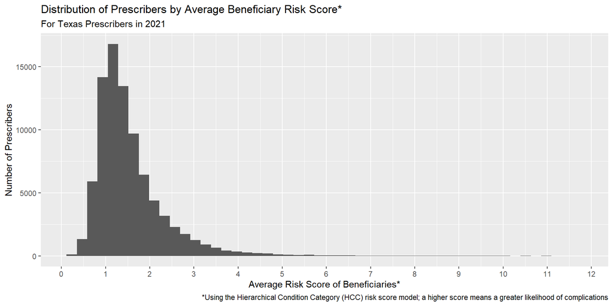

This histogram displays the distribution of average risk scores of Texas providers in 2021. The mean risk score is 1.56 and the median is 1.35. This analysis is interesting because the HCC model is normed to 1, so that an unhealthy score is more than 1 and a health score is below one (Hoffman et al., 2018). Thus, both the mean and median Texan in 2021 were considered slightly unhealthy. A further analysis that might be of interest would be the change in this distribution over time.

### Distribution of Total Compensation by Product *(fig. 4-2)*

[figure not shown]

| product_name | total_compensation | total_compensated | mean_compensation | median_compensation |
| --- | --- | --- | --- | --- |
| JARDIANCE | 2477498.9 | 30165 | 82.13 | 15.81 |
| GOLYTELY | 1639279.2 | 8 | 204909.90 | 181157.55 |
| RYBELSUS | 1537440.6 | 35146 | 43.74 | 14.81 |
| VRAYLAR | 1493590.3 | 26446 | 56.48 | 14.17 |
| UBRELVY | 1383747.9 | 27416 | 50.47 | 14.52 |
| FARXIGA | 1159737.8 | 18837 | 61.57 | 15.85 |
| ARISTADA | 1137169.2 | 8038 | 141.47 | 19.41 |
| Ozempic | 1032121.6 | 33399 | 30.90 | 14.57 |
| SABRIL | 1021307.8 | 5 | 204261.57 | 11.31 |
| XARELTO | 964215.1 | 22287 | 43.26 | 15.45 |

### Distribution of Total Compensation by Company *(fig. 4-3)*

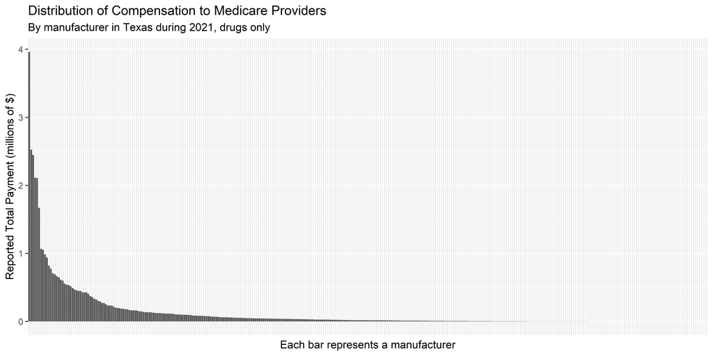

| company_name | total_compensation | total_compensated | mean_compensation | median_compensation |
| --- | --- | --- | --- | --- |
| AbbVie Inc. | 3961099.5 | 89315 | 44.35 | 15.050 |
| AstraZeneca Pharmaceuticals LP | 2524824.9 | 33541 | 75.28 | 15.890 |
| Novo Nordisk Inc | 2447607.5 | 43826 | 55.85 | 15.000 |
| Janssen Pharmaceuticals, Inc | 2113298.0 | 36829 | 57.38 | 16.040 |
| Eli Lilly and Company | 2107409.5 | 33827 | 62.30 | 15.190 |
| Sebela Pharmaceuticals Inc. | 1670860.2 | 822 | 2032.68 | 15.155 |
| Lundbeck LLC | 1066515.1 | 2809 | 379.68 | 16.600 |
| Boehringer Ingelheim Pharmaceuticals, Inc. | 1053618.2 | 21289 | 49.49 | 17.240 |
| Boehringer Ingelheim International GmbH | 985875.0 | 7 | 140839.29 | 103125.000 |
| GlaxoSmithKline, LLC. | 937454.5 | 16553 | 56.63 | 14.570 |

### Volume of Compensation by Day of Week *(fig. 4-4)*

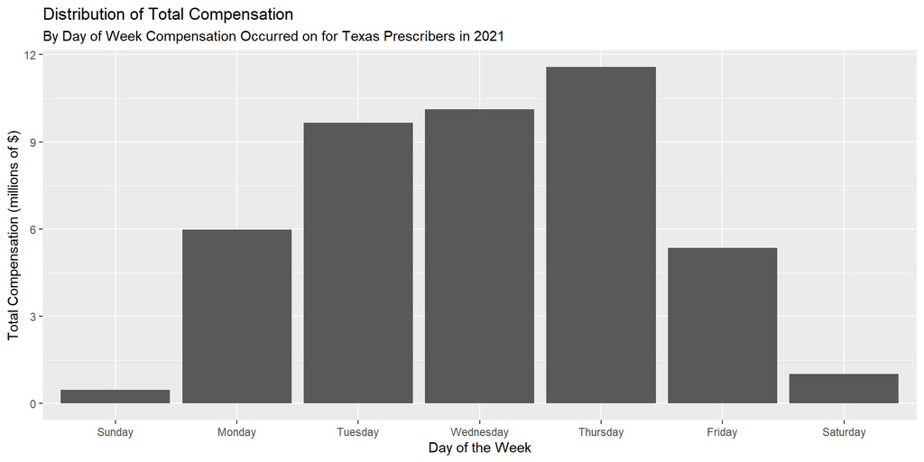

This bar plot shows on which days the most and least compensation occurs on. The mean amount of compensation across all days of the week is 65.49, and the median is 16.03. The data used to construct the plot is below:

| payment_day_of_week | total_compensation | total_compensated | mean_compensation | median_compensation |
| --- | --- | --- | --- | --- |
| Sunday | 474239.8 | 2795 | 169.67 | 16.89 |
| Monday | 5976272.7 | 105471 | 56.66 | 15.81 |
| Tuesday | 9649802.1 | 155923 | 61.89 | 16.14 |
| Wednesday | 10119396.8 | 166185 | 60.89 | 15.93 |
| Thursday | 11569500.8 | 150918 | 76.66 | 16.35 |
| Friday | 5360144.9 | 83278 | 64.36 | 15.71 |
| Saturday | 1024626.8 | 9960 | 102.87 | 16.27 |

## Multivariate Analyses (5)

### How are different specialties compensated? *(fig. 5-1)*

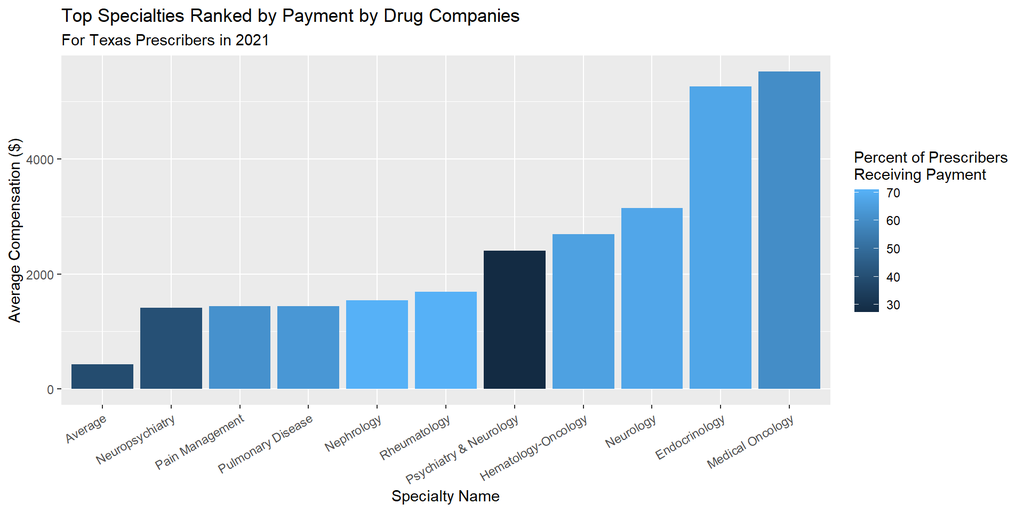

This plot adapts data from pay_by_specialty to determine compensation by specialty for specialties with more than 100 unique providers identifying as that specialty. The top ten specialties and the overall average are shown. The data used in the plot is below:

| pbr_specialty | mean_compensation | total_pbr | total_compensated |
| --- | --- | --- | --- |
| Medical Oncology | 5521.6000 | 377 | 227 |
| Endocrinology | 5262.8100 | 452 | 306 |
| Neurology | 3144.2300 | 904 | 614 |
| Hematology-Oncology | 2692.9200 | 506 | 335 |
| Psychiatry & Neurology | 2406.3200 | 851 | 234 |
| Rheumatology | 1686.8400 | 365 | 259 |
| Nephrology | 1545.2200 | 833 | 592 |
| Pulmonary Disease | 1439.3600 | 588 | 373 |
| Pain Management | 1437.2600 | 237 | 146 |
| Neuropsychiatry | 1410.5900 | 133 | 54 |
| Average | 427.8744 | 84546 | 33161 |

### How much is Medicare charged for brand/generic drugs? *(fig. 5-2)*

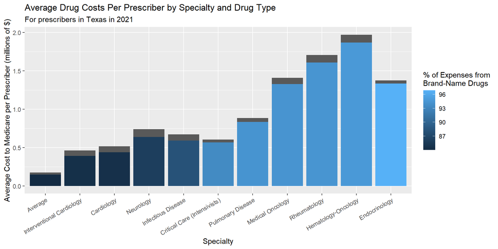

This bar graph displays a plethora of information about the top ten specialties that are overall, on average, the most expensive to Medicare. The y-axis displays average cost of all drugs a provider from each specialty on the y-axis prescribed to patients in 2021, with the average for all specialties on the left. In addition, the colored segment within each bar represents the expenses of just brand-name drugs. The shading of the colored segement is the percent of expenses Medicare is charged for brand-name drugs as a proportion of all drugs prescribed. Across the board, the correlation between brand-name drug cost and total drug cost is about r = 0.993, which demonstrates a remarkably high correlation.

### How many claims does Medicare receive for brand/generic drugs? *(fig. 5-3)*

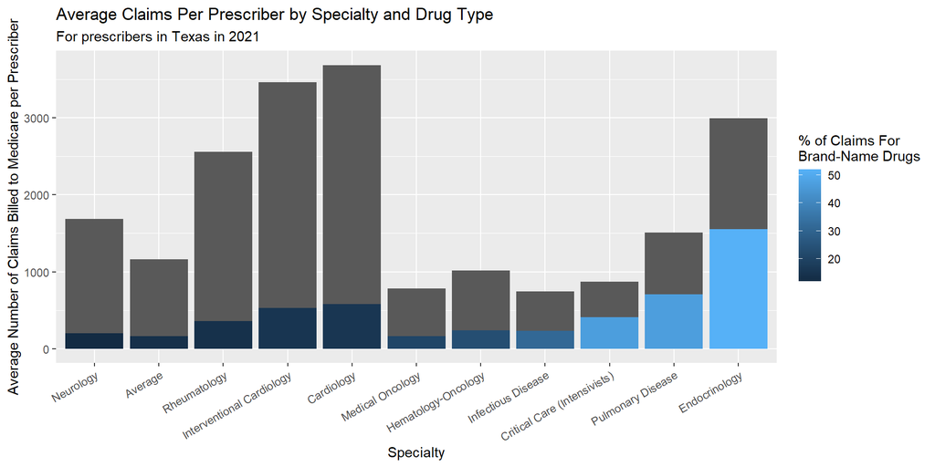

This graph shows the same specialties as *fig. 5-2*—but now in order of the proportion of *claims* that are for brand-name drugs. The y-axis depicts the number of claims per prescriber in each specialty on the x-axis, with the height of each gray bar representing the total number of claims and the height of the shaded bar presenting the number of claims for brand-name drugs. Note how in all of the specialties, brand-name drugs are an outsized contributor to overall cost. Ultimately, the statistical correlation between brand-name claims and total cost is significantly lower, but still worth mentioning at about r = 0.546.

### What effect does drug company compensation have on the types of patients doctors treat? *(fig. 5-4)*

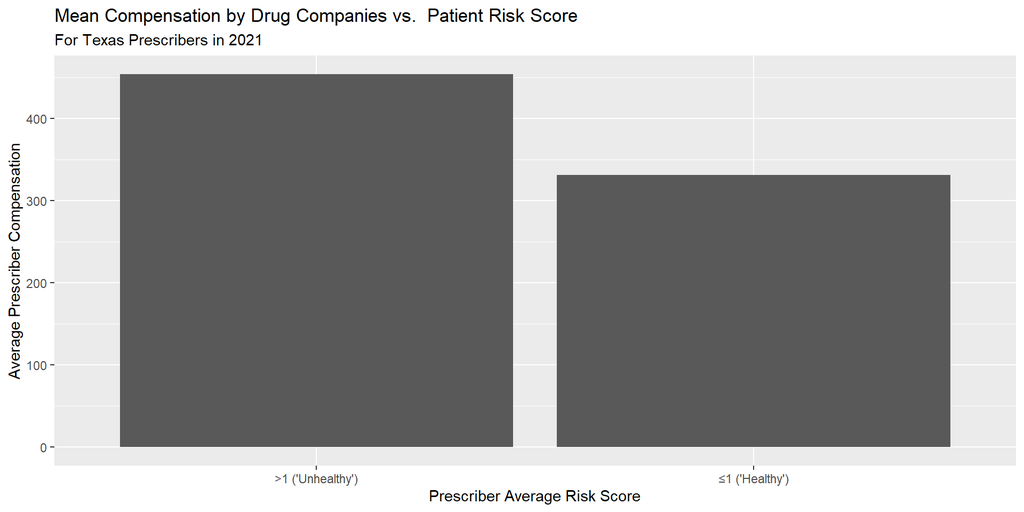

## Reproducibility (6)

The data and analyses in this report should be reproducible with minimal effort. In addition, there are many variables that were calculated that did not end up being used, but still have great potential for insightful analysis. Also, the methods used in this report should still be able to be applied to national data, however, it may not be practical to use R Markdown for such large data.

Some tips for reproducing this report:

- Make sure to double check the working directory at the top and the names of the .csv files you read!
- You may need to run some lines one at a time in the command line. The “Run Chunk” feature can get stuck sometimes.
- This report only deals with static data at a single point in time. To analyze chronological trends additional coding is needed.

## Choice Elements (7)

In-line code appears all throughout my report to include dynamic descriptive statistics that match graphs (1). The `mpd_pay` tibble is the result of a merger between the `mpd_clean` tibble and the `pay_clean` tibble (2). Many new variables of interest are created in this report, but perhaps the variables of greatest interest are the `*_compensation` variables in the `pay_by_*` tibbles, which are aggregate statistics about certain subsets and categories in the dataset (3). The dates included in the OP data are parsed as part of the process to figure out which day of the week the most compensation occurs on (4). String variables are parsed in the process of creating the `pay_by_payment_product` tibble, which has a separate entry for each non-NA value of any variable in `pay_clean` that starts with `product_name_*`, since multiple products can be associated with a single payment (5).

## Conclusion & Closing Remarks (8)

With how many different analyses were presented in this report, it can be difficult to draw one single overarching conclusion. Speaking in broad strokes, however, a few major themes were present throughout the data. First of all, it’s important to point out that the majority of Medicare prescribers receieve little or no compensation from drug companies. However, it’s equally significant to note that a non-negligble few derive a hefty income from these deals. In addition, there are certain discernable trends in how the compensation is directed. A few specific drugs and companies spend much more than all others. Also, particular days of the week and specialties recieve disproportionate compensation. Additionally, while it may be common knowledge, the data show that it is abundantly clear that brand-name drugs are creating exceptional expenses to the healthcare system. Finally, the data also offer a unique perspective into the relationship between drug company compensation and patient risk scores: apparently providers who treat less healthy patients receieve greater compensation than those who treat more healthy patients.

Overall, the most unexpected claim was that last one. I hypothesized when I first began to explore this data that providers who recieve higher compensation would be the ones who treat less risky patients since they are more involved with expensive marketed drugs rather than focused on treating patients. While I cannot claim to explain the causes for this outcome, I would speculate that rather the opposite is true—that is, that providers who deal with less-widely-used, proprietary drugs that undergo marketing are taking on patients with diseases that may not be responding to existing less-marketed, more-established treatments.

## References (9)

Centers for Medicare & Medicaid Services. (2022, June 30). *2021 General Payment Data* [Table].

Centers for Medicare & Medicaid Services. https://openpaymentsdata.cms.gov/dataset/

0380bbeb-aea1-58b6-b708-829f92a48202

Centers for Medicare & Medicaid Services. (2023, April 28). *Medicare Part D Prescribers - by

Provider* [Table]. Centers for Medicare and Medicaid Services. https://data.cms.gov/

provider-summary-by-type-of-service/medicare-part-d-prescribers/

medicare-part-d-prescribers-by-provider

Chang, J. (2009, August 25). *Re: Rotating and spacing axis labels in ggplot2* [Online forum post].

Stack Overflow. https://stackoverflow.com/questions/1330989/

rotating-and-spacing-axis-labels-in-ggplot2

Gudantova, A. (2023, May 12). *a medical mask, medical supplies, and money on a blue background*

[Photograph]. Unsplash. https://unsplash.com/photos/

a-medical-mask-medical-supplies-and-money-on-a-blue-background-l2iCYoXeBkY

Hoffman, A. F., Reiter, K. L., & Randolph, R. K. (2018). Average Beneficiary CMS

Hierarchical Condition Category (HCC) Risk Scores for Rural and Urban

Providers. *NC Rural Health Research Program*, 1.

https://www.shepscenter.unc.edu/wp-content/uploads/dlm_uploads/2018/07/

Average-Beneficiary-CMS-Hierarchical-Condition-Category-HCC-Risk-Scores-for-Rural

-and-Urban-Providers.pdf